# Лабораторна робота №4

Перевірка статистичних гіпотез щодо закону розподілу. Перевірка на нормальність

Levchenko_Dmytro

2025-12-07

## Мета роботи

Метою даної лабораторної роботи є засвоєння методів перевірки статистичних гіпотез щодо закону розподілу випадкової величини, зокрема перевірки на нормальність, а також набуття практичних навичок роботи в середовищі RStudio з використанням пакету RMarkdown.

## Генерація вибірок

У даному розділі здійснюється ініціалізація середовища R, підключення необхідних бібліотек та генерація двох випадкових вибірок обсягів $n = 50$ та $n = 1000$ із нормального закону розподілу $N(0,1)$. Для відтворюваності результатів фіксується початкове значення генератора псевдовипадкових чисел.

```r
knitr::opts_chunk$set(echo = TRUE, warning = FALSE, message = FALSE)
set.seed(123)

library(nortest)
library(ggplot2)
library(dplyr)

x50   <- rnorm(50, 0, 1)
x1000 <- rnorm(1000, 0, 1)
```

У даному розділі здійснюється ініціалізація середовища R, підключення необхідних бібліотек та генерація двох випадкових вибірок обсягів $n = 50$ та $n = 1000$ із нормального закону розподілу $N(0, 1)$. Генерація здійснюється за допомогою вбудованої функції `rnorm()`. Для відтворюваності результатів фіксується початкове значення генератора псевдовипадкових чисел.

## Числові характеристики

У даному розділі обчислюються основні числові характеристики вибірок: обсяг вибірки, вибіркове середнє значення, дисперсія, середньоквадратичне відхилення, асиметрія та ексцес. Для цього створюється користувацька функція.

```r
stats_table <- function(x){
  data.frame(
    n = length(x),
    mean = mean(x),
    var = var(x),
    sd = sd(x),
    skewness = mean((x - mean(x))^3)/sd(x)^3,
    kurtosis = mean((x - mean(x))^4)/sd(x)^4 - 3
  )
}

stats50   <- stats_table(x50)
stats1000 <- stats_table(x1000)

stats50
```

```
##    n       mean       var      sd  skewness   kurtosis
## 1 50 0.03440355 0.8572352 0.92587 0.1626919 -0.5236942
```

```r
stats1000
```

```
##      n      mean      var       sd   skewness    kurtosis
## 1 1000 0.0229725 1.007007 1.003497 0.08397494 -0.04047663
```

## Гістограми розподілу

У даному розділі будується гістограма розподілу випадкових значень для обох вибірок з накладеною оцінкою щільності розподілу. Це дозволяє наочно оцінити форму розподілу.

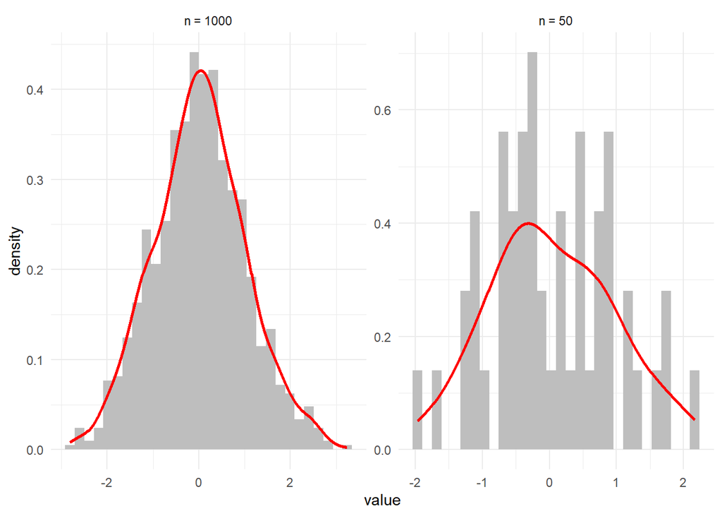

```r
df <- data.frame(
  value = c(x50, x1000),
  sample = rep(c("n = 50", "n = 1000"), c(50, 1000))
)

ggplot(df, aes(value)) +
  geom_histogram(aes(y = ..density..), bins = 30, fill = "gray") +
  geom_density(color = "red", size = 1) +
  facet_wrap(~sample, scales = "free") +
  theme_minimal()
```

## Емпірична та теоретична функції розподілу

У даному розділі будується емпірична функція розподілу та порівнюється з теоретичною функцією щільності нормального розподілу.

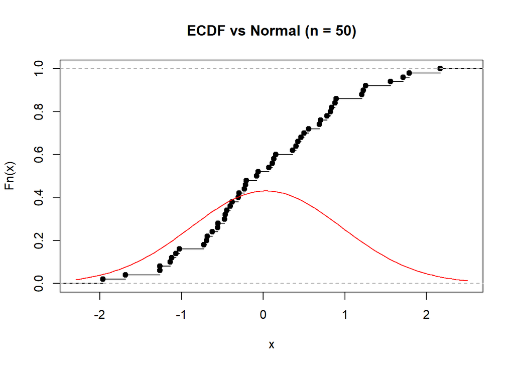

```r
plot(ecdf(x50), main = "ECDF vs Normal (n = 50)")
curve(dnorm(x, mean(x50), sd(x50)), add = TRUE, col = "red")
```

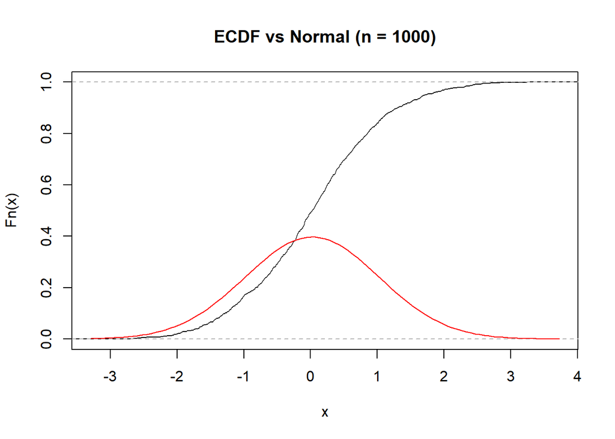

```r
plot(ecdf(x1000), main = "ECDF vs Normal (n = 1000)")
curve(dnorm(x, mean(x1000), sd(x1000)), add = TRUE, col = "red")
```

## Діаграма розмаху (Boxplot)

Діаграма розмаху дозволяє визначити наявність викидів, симетричність та розсіювання даних.

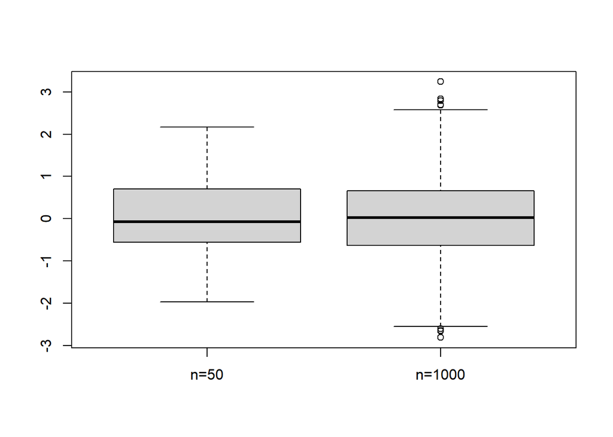

```r
boxplot(x50, x1000, names=c("n=50","n=1000"))
```

## Q-Q графік

Q-Q графік використовується для візуальної оцінки нормальності розподілу.

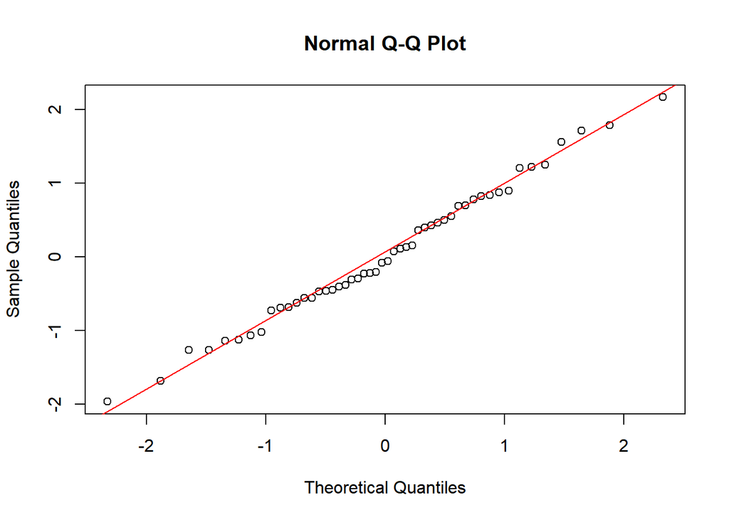

```r
qqnorm(x50)
qqline(x50, col="red")
```

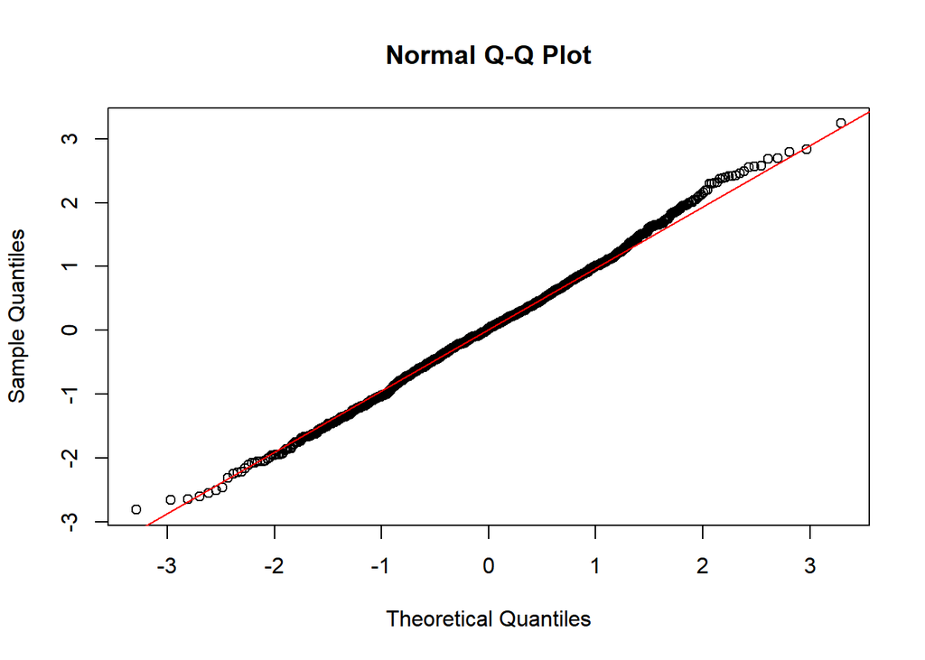

```r
qqnorm(x1000)
qqline(x1000, col="red")
```

## Тести на нормальність

У цьому розділі проводиться формальна перевірка гіпотези про нормальний розподіл за допомогою статистичних критеріїв.

```r
normal_tests <- function(x){
  data.frame(
    Shapiro = shapiro.test(x)$p.value,
    KS = ks.test(x, "pnorm", mean(x), sd(x))$p.value,
    Lilliefors = lillie.test(x)$p.value,
    Anderson = ad.test(x)$p.value,
    Cramer = cvm.test(x)$p.value,
    Pearson = pearson.test(x)$p.value,
    Shapiro_Francia = sf.test(x)$p.value
  )
}

tests50   <- normal_tests(x50)
tests1000 <- normal_tests(x1000)

tests50
```

```
##     Shapiro        KS Lilliefors  Anderson   Cramer   Pearson Shapiro_Francia
## 1 0.9278568 0.8506352  0.5233478 0.8529147 0.740691 0.4938946       0.9396819
```

```r
tests1000
```

```
##     Shapiro        KS Lilliefors  Anderson    Cramer   Pearson Shapiro_Francia
## 1 0.3010714 0.9063481  0.6117448 0.3163385 0.3289584 0.7194089       0.4147247
```

## Висновки

У ході виконання лабораторної роботи було згенеровано дві вибірки різного обсягу з нормального розподілу. За допомогою числових характеристик та графічних методів встановлено, що форма розподілу вибіркових даних є близькою до нормальної.

Проведені критерії Шапіро–Уілка, Колмогорова–Смірнова, Лілієфорса, Андерсона–Дарлінга, Крамера–фон Мізеса, Пірсона та Шапіро–Франсіа підтвердили гіпотезу про нормальність розподілу даних при рівні значущості 𝛼 = 0.05 α=0.05.

# Відповіді на контрольні питання

## 1. Які основні етапи перевірки статистичних гіпотез щодо закону розподілу і чому це важливо?

Перевірка статистичної гіпотези щодо закону розподілу складається з таких основних етапів:

1. Формулювання нульової гіпотези $H_0$ та альтернативної гіпотези $H_1$;
2. Вибір рівня значущості $\alpha$;
3. Вибір відповідного статистичного критерію;
4. Обчислення значення статистики критерію;
5. Прийняття статистичного рішення щодо підтвердження або відхилення гіпотези.

Даний процес є надзвичайно важливим, оскільки дозволяє зробити обґрунтований висновок про характер розподілу випадкової величини та забезпечує правильність подальших статистичних розрахунків і прогнозів.

## 2. Як використовувати R для визначення нормальності розподілу даних? Які функції або тести застосовуються?

У середовищі R для перевірки нормальності розподілу використовують як графічні, так і аналітичні методи. Основними статистичними тестами є:

- `shapiro.test()` — критерій Шапіро–Уілка;
- `ks.test()` — критерій Колмогорова–Смірнова;
- `lillie.test()` — критерій Лілієфорса;
- `ad.test()` — критерій Андерсона–Дарлінга;
- `cvm.test()` — критерій Крамера–фон Мізеса;
- `pearson.test()` — критерій Пірсона;
- `sf.test()` — критерій Шапіро–Франсіа.

За значенням p-value приймається рішення щодо прийняття або відхилення гіпотези про нормальність розподілу.

## 3. Як використовувати QQ-графік для оцінки нормальності розподілу?

QQ-графік (Quantile–Quantile plot) використовується для візуального порівняння вибіркового розподілу з теоретичним нормальним розподілом.  
Якщо більшість точок на графіку розташована поблизу діагональної прямої, то вибірку можна вважати такою, що підпорядковується нормальному розподілу. Істотні відхилення від прямої свідчать про порушення припущення нормальності.

## 4. Які можливі дії, якщо дані не відповідають нормальному розподілу?

Якщо вибіркові дані не відповідають нормальному розподілу, можливі такі дії:

- застосування перетворень даних (логарифмування, корінь, стандартизація);
- використання непараметричних методів статистичного аналізу;
- застосування інших моделей розподілу, які краще описують дані.

Це дозволяє зберегти коректність статистичних висновків та уникнути помилкових результатів.